# Assignment_2

```r
library(randomForest)
library(dplyr)
train_x<-train.df[,c(1:15)]
train_y<-train.df$LUNG_CANCER
rf<-randomForest(x=train_x,y=train_y,
                 ntree = 500,importance=TRUE)
test_x<-test.df[,c(1:15)]
test_y<-test.df$LUNG_CANCER
actual_values = test_y
pred_values = predict(rf,test_x)
cm = table(pred_values,actual_values)
confusionMatrix(cm)
```

```
## Confusion Matrix and Statistics
##
##            actual_values
## pred_values  0  1
##           0  4  2
##           1 11 76
##
##                Accuracy : 0.8602
##                  95% CI : (0.7728, 0.9234)
##     No Information Rate : 0.8387
##     P-Value [Acc > NIR] : 0.3461
##
##                   Kappa : 0.3181
##
##  Mcnemar's Test P-Value : 0.0265
##
##             Sensitivity : 0.26667
##             Specificity : 0.97436
##          Pos Pred Value : 0.66667
##          Neg Pred Value : 0.87356
##              Prevalence : 0.16129
##          Detection Rate : 0.04301
##    Detection Prevalence : 0.06452
##       Balanced Accuracy : 0.62051
##
##        'Positive' Class : 0
##
```

```r
varImp(rf)%>%data.frame()%>%arrange(-X1)
```

```
##                               X0         X1
## ALCOHOL.CONSUMING     11.8197323 11.8197323
## PEER_PRESSURE         11.4355185 11.4355185
## ALLERGY               10.8028221 10.8028221
## YELLOW_FINGERS         9.4297824  9.4297824
## ANXIETY                7.3462162  7.3462162
## SWALLOWING.DIFFICULTY  7.1871665  7.1871665
## GENDER                 7.1705509  7.1705509
## CHRONIC.DISEASE        6.8013875  6.8013875
## CHEST.PAIN             5.4950996  5.4950996
## FATIGUE                5.1739769  5.1739769
## WHEEZING               3.6457738  3.6457738
## COUGHING               3.3508202  3.3508202
## SHORTNESS.OF.BREATH    2.6589308  2.6589308
## AGE                    1.7778269  1.7778269
## SMOKING                0.5438715  0.5438715
```

```r
train_x<-train.df[,c(11,6)]
train_y<-train.df$LUNG_CANCER
rf<-randomForest(x=train_x,y=train_y,
                 ntree = 500,importance=TRUE)
test_x<-test.df[,c(11,6)]
test_y<-test.df$LUNG_CANCER
actual_values = test_y
pred_values = predict(rf,test_x)
cm = table(pred_values,actual_values)
confusionMatrix(cm)
```

```
## Confusion Matrix and Statistics
##
##            actual_values
## pred_values  0  1
##           0  0  0
##           1 15 78
##
##                Accuracy : 0.8387
##                  95% CI : (0.748, 0.9068)
##     No Information Rate : 0.8387
##     P-Value [Acc > NIR] : 0.5683538
##
##                   Kappa : 0
##
##  Mcnemar's Test P-Value : 0.0003006
##
##             Sensitivity : 0.0000
##             Specificity : 1.0000
##          Pos Pred Value :    NaN
##          Neg Pred Value : 0.8387
##              Prevalence : 0.1613
##          Detection Rate : 0.0000
##    Detection Prevalence : 0.0000
##       Balanced Accuracy : 0.5000
##
##        'Positive' Class : 0
##
```

### The random forest had the same variable importance as the logistic model. It also had the same accuracy for the two most useful variables as the decision tree.

```r
data = lung

unique( data$LUNG_CANCER )
```

```
## [1] 1 0
## Levels: 0 1
```

```r
ratioNoLUNG_CANCER = sum( data$LUNG_CANCER == 0 ) / sum( data$LUNG_CANCER == 1 )
ratioNoLUNG_CANCER
```

```
## [1] 0.1444444
```

```r
library('Matrix')



data_mat = sparse.model.matrix(LUNG_CANCER ~ . -LUNG_CANCER, data=data )#notice the minus LUNG_CANCER which is the dependent

library(caret)

set.seed(12345)

training_Inds = createDataPartition( data$LUNG_CANCER , p=0.7 , list=FALSE , times=1 )
testing_Inds = seq( 1 , length(data$LUNG_CANCER) )[ -training_Inds ]
training_Inds = as.vector(training_Inds)
testing_Inds = as.vector(testing_Inds)
print( paste('training inds len=',length(training_Inds),
             'testing inds len=',length(testing_Inds)) )
```

```
## [1] "training inds len= 217 testing inds len= 92"
```

```r
dim(data_mat)
```

```
## [1] 309  16
```

```r
y = as.matrix( data[,c("LUNG_CANCER")] )
x = data_mat

xtrain = x[ training_Inds , ]
ytrain = y[ training_Inds ]
xtest = x[ testing_Inds , ]
ytest = y[ testing_Inds ]



library(xgboost)
param = list(objective = "binary:logistic",
             eval_metric = "error", # "error", error is the ratio of (wrong classes/all classes)
             scale_pos_weight = ratioNoLUNG_CANCER,
             max_depth = 6,
             eta = 0.025,
             colsample_bytree = 0.5,
             min_child_weight = 1)



nrounds = 30
xgb = xgboost(params = param,
              data = xtrain,
              label = ytrain,
              nrounds = nrounds,
              verbose = 1,
              verbosity = 1)
PredictionsLUNG_CANCER = predict( xgb , xtest )

PredictionsLUNG_CANCER = ifelse( PredictionsLUNG_CANCER > 0.5 , 1 , 0 )

confusionMatrix(table(PredictionsLUNG_CANCER, ytest))
```

```
## Confusion Matrix and Statistics
##
##                       ytest
## PredictionsLUNG_CANCER  0  1
##                      0 10  9
##                      1  1 72
##
##                Accuracy : 0.8913
##                  95% CI : (0.8092, 0.9466)
##     No Information Rate : 0.8804
##     P-Value [Acc > NIR] : 0.45222
##
##                   Kappa : 0.6072
##
##  Mcnemar's Test P-Value : 0.02686
##
##             Sensitivity : 0.9091
##             Specificity : 0.8889
##          Pos Pred Value : 0.5263
##          Neg Pred Value : 0.9863
##              Prevalence : 0.1196
##          Detection Rate : 0.1087
##    Detection Prevalence : 0.2065
##       Balanced Accuracy : 0.8990
##
##        'Positive' Class : 0
##
```

```r
### with two variables now
data = lung
data <-data [,c(11,6,16)]

unique( data$LUNG_CANCER )
```

```
## [1] 1 0
## Levels: 0 1
```

```r
ratioNoLUNG_CANCER = sum( data$LUNG_CANCER == 0 ) / sum( data$LUNG_CANCER == 1 )
ratioNoLUNG_CANCER
```

```
## [1] 0.1444444
```

```r
library('Matrix')



data_mat = sparse.model.matrix(LUNG_CANCER ~ . -LUNG_CANCER, data=data )#notice the minus LUNG_CANCER which is the dependent

library(caret)

set.seed(12345)

training_Inds = createDataPartition( data$LUNG_CANCER , p=0.7 , list=FALSE , times=1 )
testing_Inds = seq( 1 , length(data$LUNG_CANCER) )[ -training_Inds ]
training_Inds = as.vector(training_Inds)
testing_Inds = as.vector(testing_Inds)
print( paste('training inds len=',length(training_Inds),
             'testing inds len=',length(testing_Inds)) )
```

```
## [1] "training inds len= 217 testing inds len= 92"
```

```r
dim(data_mat)
```

```
## [1] 309   3
```

```r
y = as.matrix( data[,c("LUNG_CANCER")] )
x = data_mat

xtrain = x[ training_Inds , ]
ytrain = y[ training_Inds ]
xtest = x[ testing_Inds , ]
ytest = y[ testing_Inds ]



library(xgboost)

param = list(objective = "binary:logistic",
             eval_metric = "error", # "error", error is the ratio of (wrong classes/all classes)
             scale_pos_weight = ratioNoLUNG_CANCER,
             max_depth = 6,
             eta = 0.025,
             colsample_bytree = 0.5,
             min_child_weight = 1)



nrounds = 30
xgb = xgboost(params = param,
              data = xtrain,
              label = ytrain,
              nrounds = nrounds,
              verbose = 1,
              verbosity = 1)
PredictionsLUNG_CANCER = predict( xgb , xtest )

PredictionsLUNG_CANCER = ifelse( PredictionsLUNG_CANCER > 0.5 , 1 , 0 )

confusionMatrix(table(PredictionsLUNG_CANCER, ytest))
```

```
## Confusion Matrix and Statistics
##
##                       ytest
## PredictionsLUNG_CANCER  0  1
##                      0  8  9
##                      1  3 72
##
##                Accuracy : 0.8696
##                  95% CI : (0.7832, 0.9307)
##     No Information Rate : 0.8804
##     P-Value [Acc > NIR] : 0.6960
##
##                   Kappa : 0.4986
##
##  Mcnemar's Test P-Value : 0.1489
##
##             Sensitivity : 0.72727
##             Specificity : 0.88889
##          Pos Pred Value : 0.47059
##          Neg Pred Value : 0.96000
##              Prevalence : 0.11957
##          Detection Rate : 0.08696
##    Detection Prevalence : 0.18478
##       Balanced Accuracy : 0.80808
##
##        'Positive' Class : 0
##
```

### When using all variables, the model has an accuracy of 89.13%. When using only peer pressure and alcohol consumption we only have a reduction to 86.96%

### Based on the accuracy, we would choose the logistic model.

### 2. Produce a set of ROC curves for the previous models

```r
library(pROC)
# logistic roc
roc <- roc(train.df$LUNG_CANCER, logistic$fitted.values)
auc(roc)
```

```
## Area under the curve: 0.9738
```

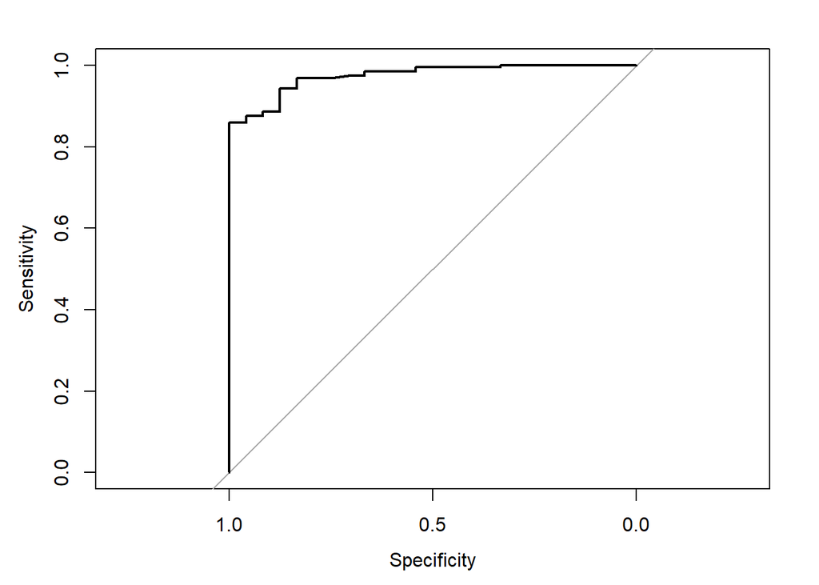

```r
plot(roc)
```

```r
# tree roc
tree.roc <- roc(test.df$LUNG_CANCER, as.numeric(tree_pred))
print(tree.roc)
```

```
##
## Call:
## roc.default(response = test.df$LUNG_CANCER, predictor = as.numeric(tree_pred))
##
## Data: as.numeric(tree_pred) in 15 controls (test.df$LUNG_CANCER 0) < 78 cases (test.df$LUNG_CANCER 1).
## Area under the curve: 0.5538
```

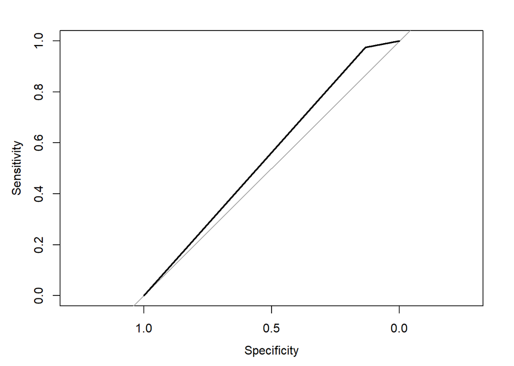

```r
plot(tree.roc)
```

```r
# forest roc
forest.roc <- roc(test.df$LUNG_CANCER, as.numeric(pred_values))
print(forest.roc)
```

```
##
## Call:
## roc.default(response = test.df$LUNG_CANCER, predictor = as.numeric(pred_values))
##
## Data: as.numeric(pred_values) in 15 controls (test.df$LUNG_CANCER 0) < 78 cases (test.df$LUNG_CANCER 1).
## Area under the curve: 0.5
```

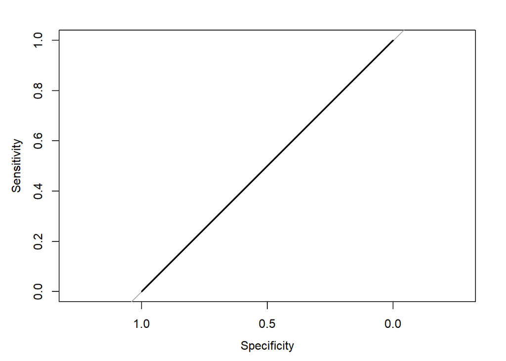

```r
plot(forest.roc)
```

### 3. Are there any variables which can be removed which do not change substantially the accuracy?

```r
logistic3 <- glm(LUNG_CANCER ~  AGE + SMOKING + YELLOW_FINGERS + ANXIETY +
    PEER_PRESSURE + CHRONIC.DISEASE + FATIGUE + ALLERGY + WHEEZING +
    ALCOHOL.CONSUMING + COUGHING + SHORTNESS.OF.BREATH + SWALLOWING.DIFFICULTY +
    CHEST.PAIN, family = binomial(), train.df)
summary(logistic3)
```

```
##
## Call:
## glm(formula = LUNG_CANCER ~ AGE + SMOKING + YELLOW_FINGERS +
##     ANXIETY + PEER_PRESSURE + CHRONIC.DISEASE + FATIGUE + ALLERGY +
##     WHEEZING + ALCOHOL.CONSUMING + COUGHING + SHORTNESS.OF.BREATH +
##     SWALLOWING.DIFFICULTY + CHEST.PAIN, family = binomial(),
##     data = train.df)
##
## Deviance Residuals:
##      Min        1Q    Median        3Q       Max
## -2.40813   0.00127   0.01841   0.08645   1.84733
##
## Coefficients:
##                         Estimate Std. Error z value Pr(>|z|)
## (Intercept)           -42.806927  14.385711  -2.976  0.00292 **
## AGE                     0.003774   0.043070   0.088  0.93018
## SMOKING                 0.634561   1.305054   0.486  0.62680
## YELLOW_FINGERS          1.729544   1.493130   1.158  0.24673
## ANXIETY                 4.789151   2.610285   1.835  0.06655 .
## PEER_PRESSURE           4.655415   2.186597   2.129  0.03325 *
## CHRONIC.DISEASE         6.077194   2.998678   2.027  0.04270 *
## FATIGUE                 2.969599   1.486656   1.998  0.04577 *
## ALLERGY                 1.975088   1.144099   1.726  0.08429 .
## WHEEZING                1.440232   1.540994   0.935  0.34999
## ALCOHOL.CONSUMING       4.342572   1.940026   2.238  0.02519 *
## COUGHING                2.932627   1.746316   1.679  0.09309 .
## SHORTNESS.OF.BREATH    -0.226836   1.603163  -0.141  0.88748
## SWALLOWING.DIFFICULTY   1.095451   2.299685   0.476  0.63383
## CHEST.PAIN             -0.160029   1.033466  -0.155  0.87694
## ---
## Signif. codes:  0 '***' 0.001 '**' 0.01 '*' 0.05 '.' 0.1 ' ' 1
##
## (Dispersion parameter for binomial family taken to be 1)
##
##     Null deviance: 150.695  on 215  degrees of freedom
## Residual deviance:  52.266  on 201  degrees of freedom
## AIC: 82.266
##
## Number of Fisher Scoring iterations: 10
```

```r
pdata3 <- predict(logistic3, newdata = test.df, type = "response")
pdata3 <- ifelse(pdata2>0.5, 1, 0)
pdata3 <- as.factor(pdata2)

library(caret)
confusionMatrix(pdata3, test.df$LUNG_CANCER)
```

```
## Confusion Matrix and Statistics
##
##           Reference
## Prediction  0  1
##          0  0  0
##          1 15 78
##
##                Accuracy : 0.8387
##                  95% CI : (0.748, 0.9068)
##     No Information Rate : 0.8387
##     P-Value [Acc > NIR] : 0.5683538
##
##                   Kappa : 0
##
##  Mcnemar's Test P-Value : 0.0003006
##
##             Sensitivity : 0.0000
##             Specificity : 1.0000
##          Pos Pred Value :    NaN
##          Neg Pred Value : 0.8387
##              Prevalence : 0.1613
##          Detection Rate : 0.0000
##    Detection Prevalence : 0.0000
##       Balanced Accuracy : 0.5000
##
##        'Positive' Class : 0
##
```

## Question 3

### Load Data

```r
amz<-read.csv("amazon_co-ecommerce_sample.csv")
library(stringr)
library(readr)
amz$price <- parse_number(amz$price)
amz$number_available_in_stock <- parse_number(amz$number_available_in_stock)
amz$average_review_rating <- substr(amz$average_review_rating, start = 1, stop = 3)

data=amz[,c(4,5,6,7,8)]
summary(data)
```

```
##      price         number_available_in_stock number_of_reviews
##  Min.   :   0.01   Min.   : 1.000            Length:10000
##  1st Qu.:   4.99   1st Qu.: 3.000            Class :character
##  Median :  10.62   Median : 5.000            Mode  :character
##  Mean   :  20.28   Mean   : 7.917
##  3rd Qu.:  19.99   3rd Qu.:10.000
##  Max.   :2439.92   Max.   :92.000
##  NA's   :1435      NA's   :2500
##  number_of_answered_questions average_review_rating
##  Min.   : 1.000               Length:10000
##  1st Qu.: 1.000               Class :character
##  Median : 1.000               Mode  :character
##  Mean   : 1.835
##  3rd Qu.: 2.000
##  Max.   :39.000
##  NA's   :765
```

```r
data=na.omit(data)
data$number_of_reviews<-as.numeric(data$number_of_reviews)
data$average_review_rating<-as.numeric(data$average_review_rating)

summary(data)
```

```
##      price         number_available_in_stock number_of_reviews
##  Min.   :   0.29   Min.   : 1.000            Min.   :  1.00
##  1st Qu.:   5.98   1st Qu.: 3.000            1st Qu.:  1.00
##  Median :  11.66   Median : 5.000            Median :  2.00
##  Mean   :  20.57   Mean   : 8.731            Mean   : 10.91
##  3rd Qu.:  20.97   3rd Qu.:11.000            3rd Qu.:  8.00
##  Max.   :2439.92   Max.   :92.000            Max.   :802.00
##                                              NA's   :16
##  number_of_answered_questions average_review_rating
##  Min.   : 1.000               Min.   :2.300
##  1st Qu.: 1.000               1st Qu.:4.500
##  Median : 1.000               Median :4.900
##  Mean   : 1.835               Mean   :4.695
##  3rd Qu.: 2.000               3rd Qu.:5.000
##  Max.   :39.000               Max.   :5.000
##                               NA's   :14
```

```r
data=na.omit(data)
summary(data)
```

```
##      price         number_available_in_stock number_of_reviews
##  Min.   :   0.29   Min.   : 1.000            Min.   :  1.00
##  1st Qu.:   5.98   1st Qu.: 3.000            1st Qu.:  1.00
##  Median :  11.62   Median : 5.000            Median :  2.00
##  Mean   :  20.57   Mean   : 8.702            Mean   : 10.91
##  3rd Qu.:  20.95   3rd Qu.:11.000            3rd Qu.:  8.00
##  Max.   :2439.92   Max.   :92.000            Max.   :802.00
##  number_of_answered_questions average_review_rating
##  Min.   : 1.000               Min.   :2.300
##  1st Qu.: 1.000               1st Qu.:4.500
##  Median : 1.000               Median :4.900
##  Mean   : 1.833               Mean   :4.695
##  3rd Qu.: 2.000               3rd Qu.:5.000
##  Max.   :39.000               Max.   :5.000
```

### 1. Produce 3 models to predict the price and use a 70/30 training testing split. Report on the mean squared error (MSE) for each model in testing.

```r
# I will be doing a linear regression, decision tree and logistic regression
set.seed(12345)
train.index <- sample(row.names(data), 0.7*dim(data)[1])
test.index <- setdiff(row.names(data), train.index)
train.df <- data[train.index, ]
test.df <- data[test.index, ]

model1 <- lm(price~.,data=train.df)
sm1 <- summary(model1)

pred <- predict(model1,test.df)
mse1 <- mean((data$price - pred)^2,na.rm=T)
# random forest
library(randomForest)
train_x<-train.df[,c(2:5)]
train_y<-train.df$price
rf<-randomForest(x=train_x,y=train_y,
                 ntree = 500,importance=TRUE)
test_x<-test.df[,c(2:5)]
test_y<-test.df$price
actual_values = test_y
pred_values = predict(rf,test_x)
cm = table(pred_values,actual_values)

mse2 <- mean((data$price - pred_values)^2,na.rm=T)
#decision tree
model3 <- rpart(price~., data = train.df)
pred3 <- predict(model3,test.df)

mse3 <- mean((data$price - pred3)^2,na.rm=T)
mse1
```

```
## [1] 2261.435
```

```r
mse2
```

```
## [1] 2275.78
```

```r
mse3
```

```
## [1] 2256.966
```

### 2. Produce a column with a price label for whether the price is above or below the average. Produce 3 models with 70/30 split to predict the binary label and report on the accuracy

```r
amz<-read.csv("amazon_co-ecommerce_sample.csv")
library(stringr)
library(readr)
amz$price <- parse_number(amz$price)
amz$number_available_in_stock <- parse_number(amz$number_available_in_stock)
amz$average_review_rating <- substr(amz$average_review_rating, start = 1, stop = 3)

data=amz[,c(4,5,6,7,8)]
summary(data)
```

```
##      price         number_available_in_stock number_of_reviews
##  Min.   :   0.01   Min.   : 1.000            Length:10000
##  1st Qu.:   4.99   1st Qu.: 3.000            Class :character
##  Median :  10.62   Median : 5.000            Mode  :character
##  Mean   :  20.28   Mean   : 7.917
##  3rd Qu.:  19.99   3rd Qu.:10.000
##  Max.   :2439.92   Max.   :92.000
##  NA's   :1435      NA's   :2500
##  number_of_answered_questions average_review_rating
##  Min.   : 1.000               Length:10000
##  1st Qu.: 1.000               Class :character
##  Median : 1.000               Mode  :character
##  Mean   : 1.835
##  3rd Qu.: 2.000
##  Max.   :39.000
##  NA's   :765
```

```r
data=na.omit(data)
data$number_of_reviews<-as.numeric(data$number_of_reviews)
data$average_review_rating<-as.numeric(data$average_review_rating)

summary(data)
```

```
##      price         number_available_in_stock number_of_reviews
##  Min.   :   0.29   Min.   : 1.000            Min.   :  1.00
##  1st Qu.:   5.98   1st Qu.: 3.000            1st Qu.:  1.00
##  Median :  11.66   Median : 5.000            Median :  2.00
##  Mean   :  20.57   Mean   : 8.731            Mean   : 10.91
##  3rd Qu.:  20.97   3rd Qu.:11.000            3rd Qu.:  8.00
##  Max.   :2439.92   Max.   :92.000            Max.   :802.00
##                                              NA's   :16
##  number_of_answered_questions average_review_rating
##  Min.   : 1.000               Min.   :2.300
##  1st Qu.: 1.000               1st Qu.:4.500
##  Median : 1.000               Median :4.900
##  Mean   : 1.835               Mean   :4.695
##  3rd Qu.: 2.000               3rd Qu.:5.000
##  Max.   :39.000               Max.   :5.000
##                               NA's   :14
```

```r
data=na.omit(data)
summary(data)
```

```
##      price         number_available_in_stock number_of_reviews
##  Min.   :   0.29   Min.   : 1.000            Min.   :  1.00
##  1st Qu.:   5.98   1st Qu.: 3.000            1st Qu.:  1.00
##  Median :  11.62   Median : 5.000            Median :  2.00
##  Mean   :  20.57   Mean   : 8.702            Mean   : 10.91
##  3rd Qu.:  20.95   3rd Qu.:11.000            3rd Qu.:  8.00
##  Max.   :2439.92   Max.   :92.000            Max.   :802.00
##  number_of_answered_questions average_review_rating
##  Min.   : 1.000               Min.   :2.300
##  1st Qu.: 1.000               1st Qu.:4.500
##  Median : 1.000               Median :4.900
##  Mean   : 1.833               Mean   :4.695
##  3rd Qu.: 2.000               3rd Qu.:5.000
##  Max.   :39.000               Max.   :5.000
```

```r
averagep <- mean(data$price)
data$price<-ifelse(data$price>averagep,1,0)

set.seed(12345)
train.index <- sample(row.names(data), 0.7*dim(data)[1])
test.index <- setdiff(row.names(data), train.index)
train.df <- data[train.index, ]
test.df <- data[test.index, ]

#logistic
logistic4 <- glm(price ~ ., family = binomial(), train.df)
summary(logistic4)
```

```
##
## Call:
## glm(formula = price ~ ., family = binomial(), data = train.df)
##
## Deviance Residuals:
##     Min       1Q   Median       3Q      Max
## -1.2132  -0.7781  -0.7373  -0.2986   1.9410
##
## Coefficients:
##                               Estimate Std. Error z value Pr(>|z|)
## (Intercept)                  -2.465243   0.487598  -5.056 4.28e-07 ***
## number_available_in_stock     0.006836   0.004019   1.701  0.08899 .
## number_of_reviews            -0.003122   0.001511  -2.066  0.03884 *
## number_of_answered_questions  0.027410   0.015536   1.764  0.07768 .
## average_review_rating         0.273386   0.102485   2.668  0.00764 **
## ---
## Signif. codes:  0 '***' 0.001 '**' 0.01 '*' 0.05 '.' 0.1 ' ' 1
##
## (Dispersion parameter for binomial family taken to be 1)
##
##     Null deviance: 4618.5  on 4108  degrees of freedom
## Residual deviance: 4600.5  on 4104  degrees of freedom
## AIC: 4610.5
##
## Number of Fisher Scoring iterations: 4
```

```r
pdata4 <- predict(logistic4, newdata = test.df, type = "response")
pdata4 <- ifelse(pdata4>0.5, 1, 0)
pdata4 <- as.factor(pdata4)
test.df$price <- as.factor(test.df$price)
library(caret)
confusionMatrix(pdata4, test.df$price)
```

```
## Confusion Matrix and Statistics
##
##           Reference
## Prediction    0    1
##          0 1302  459
##          1    0    0
##
##                Accuracy : 0.7394
##                  95% CI : (0.7182, 0.7597)
##     No Information Rate : 0.7394
##     P-Value [Acc > NIR] : 0.5126
##
##                   Kappa : 0
##
##  Mcnemar's Test P-Value : <2e-16
##
##             Sensitivity : 1.0000
##             Specificity : 0.0000
##          Pos Pred Value : 0.7394
##          Neg Pred Value :    NaN
##              Prevalence : 0.7394
##          Detection Rate : 0.7394
##    Detection Prevalence : 1.0000
##       Balanced Accuracy : 0.5000
##
##        'Positive' Class : 0
##
```

```r
#decision tree
dec_tree4 <- rpart(price ~., data = train.df)
#rpart.plot(dec_tree)
summary(dec_tree4)
```

```
## Call:
## rpart(formula = price ~ ., data = train.df)
##   n= 4109
##
##            CP nsplit rel error xerror xstd
## 1 0.006771975      0         1      0    0
##
## Node number 1: 4109 observations
##   mean=0.2496958, MSE=0.1873478
```

```r
tree_pred4 <- predict(dec_tree4,
                    newdata = test.df)

tree_pred4 <- ifelse(tree_pred4>0.5, 1, 0)
tree_pred4 <- as.factor(tree_pred4)
confusionMatrix(tree_pred4, test.df$price)
```

```
## Confusion Matrix and Statistics
##
##           Reference
## Prediction    0    1
##          0 1302  459
##          1    0    0
##
##                Accuracy : 0.7394
##                  95% CI : (0.7182, 0.7597)
##     No Information Rate : 0.7394
##     P-Value [Acc > NIR] : 0.5126
##
##                   Kappa : 0
##
##  Mcnemar's Test P-Value : <2e-16
##
##             Sensitivity : 1.0000
##             Specificity : 0.0000
##          Pos Pred Value : 0.7394
##          Neg Pred Value :    NaN
##              Prevalence : 0.7394
##          Detection Rate : 0.7394
##    Detection Prevalence : 1.0000
##       Balanced Accuracy : 0.5000
##
##        'Positive' Class : 0
##
```

```r
#random forest
train_x<-train.df[,c(2:5)]
train_y<-train.df$price
rf<-randomForest(x=train_x,y=train_y,
                 ntree = 500,importance=TRUE)
test_x<-test.df[,c(2:5)]
test_y<-test.df$price
actual_values = test_y
pred_values = predict(rf,test_x)
cm = table(pred_values,actual_values)
#confusionMatrix(cm)
```

### 3. Produce a ROC curve for the 3 models used to predict the binary price label and comment on the result for the different models.

```r
roc_log4 <- roc(train.df$price, logistic4$fitted.values)
auc(roc_log4)
```

```
## Area under the curve: 0.5464
```

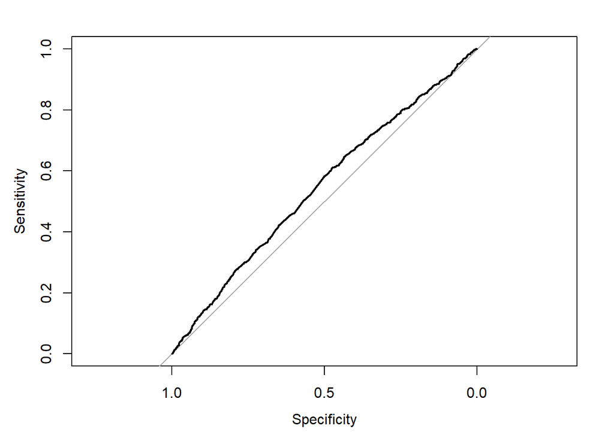

```r
plot(roc_log4)
```

```r
tree.roc4 <- roc(test.df$price, as.numeric(tree_pred4))
print(tree.roc4)
```

```
##
## Call:
## roc.default(response = test.df$price, predictor = as.numeric(tree_pred4))
##
## Data: as.numeric(tree_pred4) in 1302 controls (test.df$price 0) < 459 cases (test.df$price 1).
## Area under the curve: 0.5
```

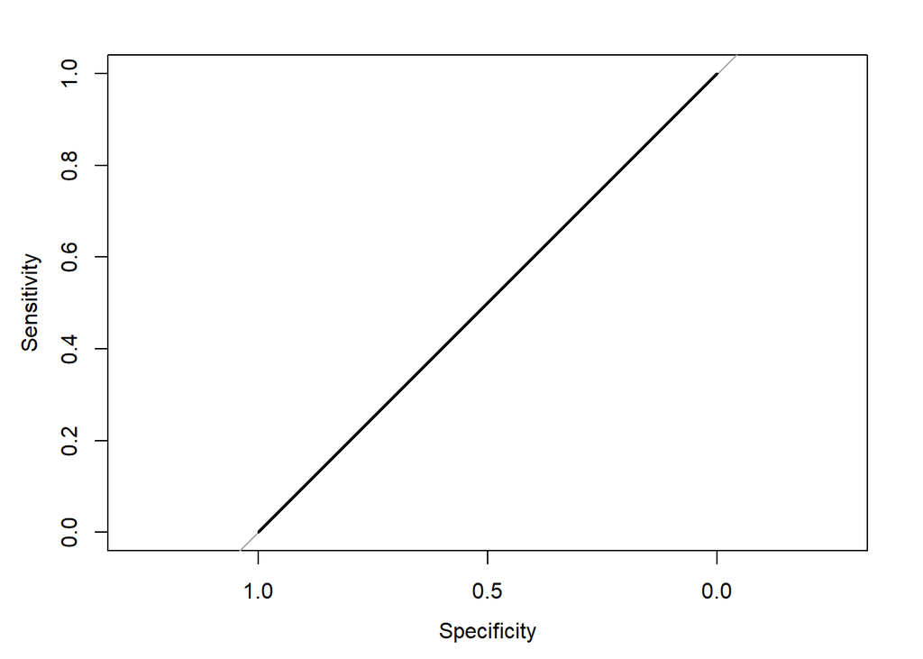

```r
plot(tree.roc4)
```

```r
# forest roc
forest.roc4 <- roc(test.df$price, as.numeric(pred_values))
print(forest.roc4)
```

```
##
## Call:
## roc.default(response = test.df$price, predictor = as.numeric(pred_values))
##
## Data: as.numeric(pred_values) in 1302 controls (test.df$price 0) < 459 cases (test.df$price 1).
## Area under the curve: 0.5639
```

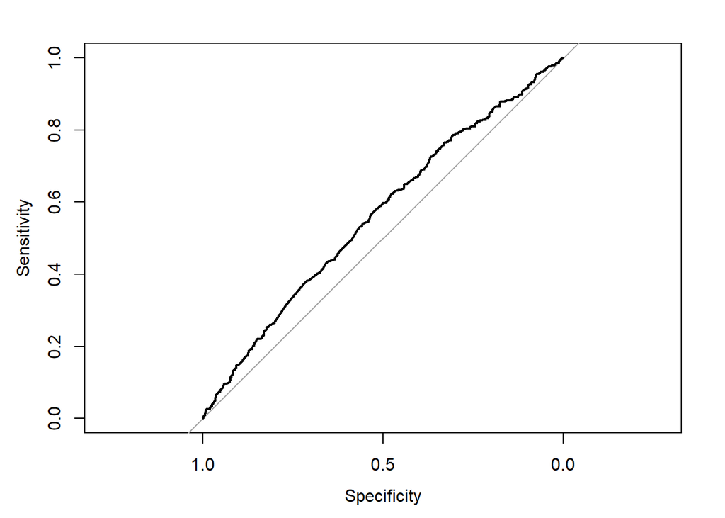

```r
plot(forest.roc4)
```